# QC cases log

Jaime Abraham Castro-Mondragon & Jean-Marc Costanzi

Last update: 2026-10-07

## 1 Introduction

This document shows a list of *special* cases that are recurrently observed during the process of DNA variants *QC*.

The document is divided in different categories:

- PC: Possible contamination. Examples of how to deal when a sample is tagged as contaminated.
- IE: Include/Exclude variants. Examples of how to adjust of verify the selection criterion of a variant.
- RV: Examples of recurrent variant in InPreD samples, listed here to remember to exclude them in the QC process.
- DC: Discordant cases. Examples when annotation and prediction data does not coincide.

Each example contains a paragraph with the biological or technical explanation of the case and its solution (i.e., how to proceed in case we encounter one case of these during the QC process).

This document will be regularly expanded as more special cases are detected during the DNA variants QC process.

## 2 Concepts

- **CNV**: Copy Number Variant. A genomic event in which sections of the genome are repeated and the number of repeats in the genome varies between individuals. It is a type of structural variation (duplication or deletion event) that affects a considerable number of base pairs.
- **Coverage MAD CNV**: the median absolute deviation of normalized CNVs. Higher values indicate noisier sample data (poor quality). It helps ensure that genomic alterations (deletions or duplications) are actual biological findings rather than technical artifacts.
- **DNA/RNA conconcordance**: a score that measures how closely genetic alterations found in DNA (the genome) align with the corresponding RNA transcripts (the transcriptome). A high concordance score (close to 1) indicates that the DNA variants are well represented in the RNA, suggesting that they are likely to be biologically relevant and not artifacts.
- **GL_P**: germline proximity. Variant classification category in which the variant did not pass the VAF-based germline variant proximity filter, which looks for 5 or more known germline variants with similar VAFs on the same chromosome.
- **LOH**: loss of heterozygosity. A genetic event that results in the loss of one of its two different alleles (variants) for a gene, leaving it with only a single allele across that chromosome region.
- **VAF**: Variant Allele Frequency. The proportion of sequencing reads that display a specific genetic variant compared to the total reads at that specific genomic location.

## 3 PC: Possible Contamination

*TSOPPI* estimates the level of contamination in each samples, a contamination score and its corresponding p-value are calculated. When a sample is above the predefined thresholds, it is tagged as contamination (Figure 1).

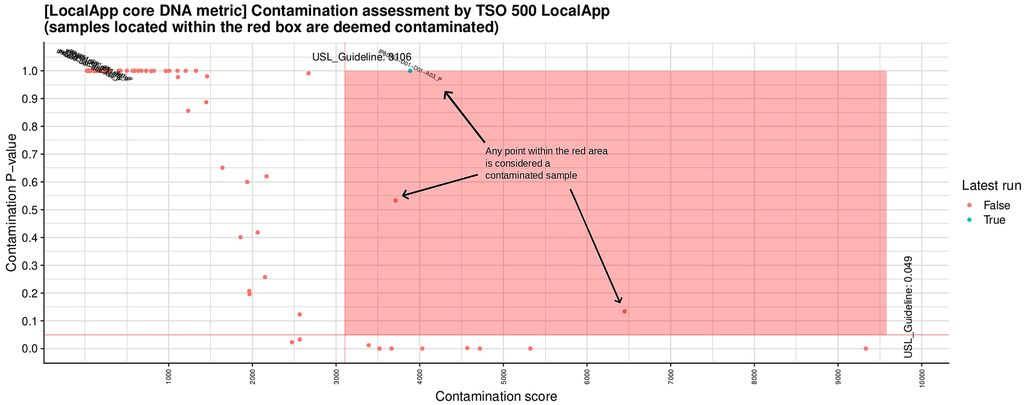

**Figure 1.** Example of samples tagged as contaminated (TSOPPI output)

### 3.1 PC1: Real Low Contamination

This is an example of real yet low degree contamination. The plot in **Figure 2** shows the *VAF* of variants within a sample (y-axis) along the genome (x-axis, chromosomes).

The area highlighted in the red box shows that many variants in this samples have a *VAF* near of 0.1. In normal conditions, we expect to observe a few variants with this value, however when many variants have similar VAF along the whole genome we can suspect a case of true contamination.

**Explanation**: it is likely that these variants with low VAF correspond to another sample, this is a clear signal of contamination.

**Solution**: as in this case the contamination degree is low, we suggest to discard all the mutations in this sample with low VAF (< 0.2).

**Sample**: *IPA0652*

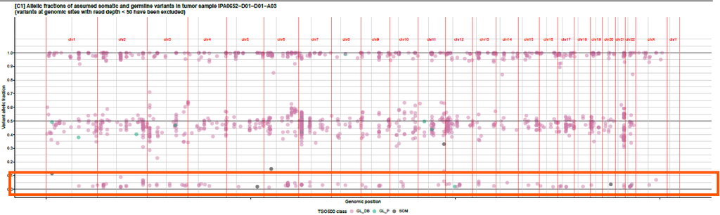

**Figure 2.** Example of samples tagged as contaminated (TSOPPI output)

### 3.2 PC2: Predicted Contamination due to CNVs

In this example the sample was tagged as contaminated (Figure 3), but when we look at its corresponding VAF plot (Figure 4) we notice a different pattern compared to the one we observed in the case *PC1* (Figure 2).

We don’t see a block of low-VAF variants along the genome (Figure 4; compare to case *PC1*). But we observe many regions along the genome with loss of heterozygosity, suggesting that this sample present multiple cases of chromosomal aberrations.

The Coverage MAD of this sample (Figure 5) is higher than the suggested threshold, which suggest that many regions in the genome are amplified or deleted, more than it is usually expected, indicating a high degree of genomic aberration.

**Explanation**: the *contamination* tag in this sample is explained by the high CNV values (MAD coverage CNV), affecting the VAF of many variants.

**Solution**: we inform the interpreters that this *contaminated* sample is indeed, not a contamination event but a high degree of chromosome aberrations in the tagged sample.

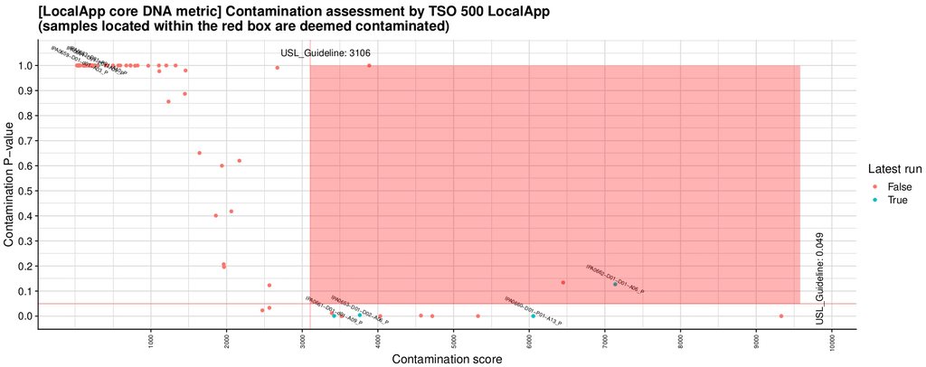

**Figure 3.** Example of sample tagged as contaminated (TSOPPI output)

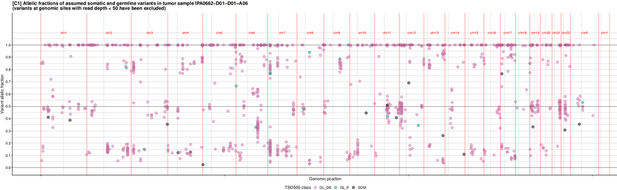

**Figure 4.** VAF plot of a sample labeled as contaminated.

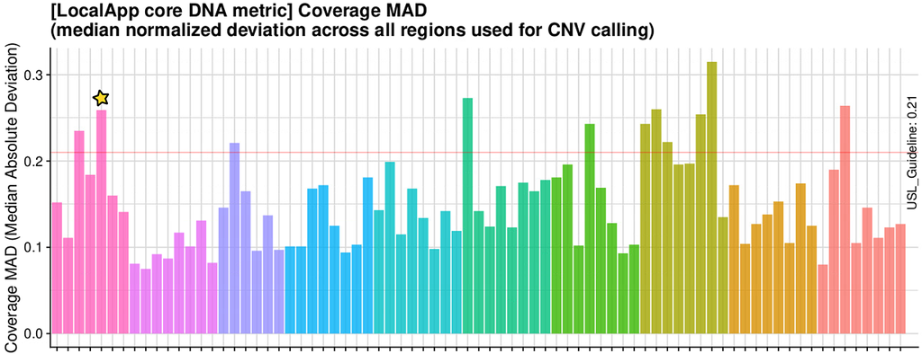

**Figure 5.** MAD coverage CNV values for different samples, each bar correspond to a sample. The yellow star highlights the sample in the case PC2. The horizontal pink line marks the MAD CNV threshold (0.21).

### 3.3 PC3: High LOH but flagged as Contamination

In this case a sample was tagged as contaminated but after a careful look in the *VAF* plot we observe a high *LOH* in many regions that could explain why this sample was tagged as contaminated.

First we noticed in the contamination score plot (Figure 6) that shows a high contamination score but a low p-value. The sample is within the contamination red area, however it is just above the threshold in the *Y-axis* and with a high yet moderate contamination score. As this sample (IPA0748) is within the red area, it is automatically tagged as **contaminated**.

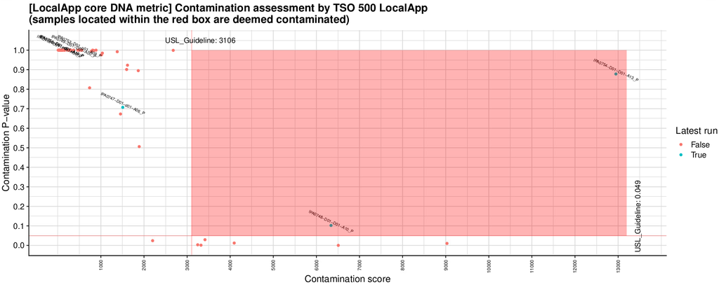

**Figure 6.** A sample flagged as contaminated but with a low p-value. The sample (IPA0748) p-value is just above the threshold in the Y-axis and with a high but moderate contamination score.

Then we looked to the *VAF plot* (Figure 7) and we observed a high *LOH* in many regions of the genome. *LOH* in this case is seen as a shift of the *VAF* of many variants in the genome, from the expected 0.5 (central band of variants) to a value close to 0.8 or 0.2 (no band). This is a clear signal of *LOH* in many regions of the genome.

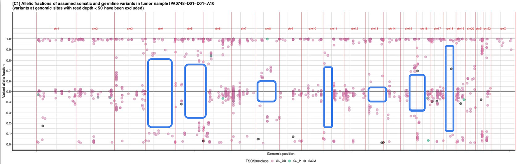

**Figure 7.** The VAF plot shows many regions with loss of heterozygosity (LOH) in many chromosomes, highlighted as a blue rectangles. Notice the separation among the VAF of the variants in the same region (x-axis) as the rectangles.

**Explanation**: the *contamination* tag in this sample is explained by the high *LOH* along the genome affecting the VAF of many variants.

**Solution**: we inform the interpreters that this sample is not a contamination event but a high degree of *LOH*.

**Sample**: *IPA0748*

## 4 IE: Include/Exclude variants

Every protein coding variant is manually inspected by the curators. *TSOPPI* considers different criteria (VAF, frequency, germline mutations, recurrent population variants, blacklisted regions) to categorize the variants as *include* or *exclude* categories.

Although a variants is categorized as *exclude*, we have to double check in case it should be *include*d in the final report.

In most of the cases it is easy to corroborate when a variant should be *include*d or *exclude*d, we recurrently found cases that are not easily categorized and require discussion and pay attention to many factors to agree in the final inclusion criteria.

### 4.1 IE1: Corroborate exclusion of *GL_P*-tagged variants

In this case, a *RAD54L* variant (chromosome 1) was tagged as *exclude* in the *Class judgement* column and assigned to the class *GL_P* (germline proximity; Figure 8).

The tag *GL_P* (germline proximity) is assigned when the VAF of this variant differs from the VAF of other nearby known germline variants. In this case, this variant is annotated as a *germline population variant* (Figure 8).

We can see the VAF of the proximal variants in the VAF plot (Figure 9). Although proximal in the genome, their VAF differs.

**Explanation**: the *germline population* tag in this variant is a criterion to *exclude* this variant. We corroborate this decision through the VAF plot.

**Solution**: the variant remains *exclude*d. No need to modify anything.

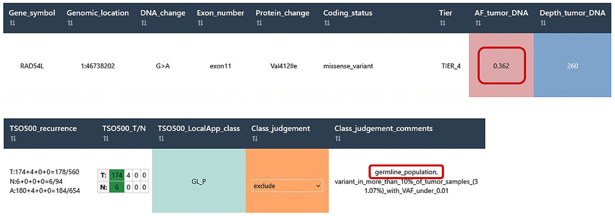

**Figure 8.** QC table with the details (VAF, frequency, sequency depth) associated to the RAD54L variant and tagged as *exclude* and *GL_P*.

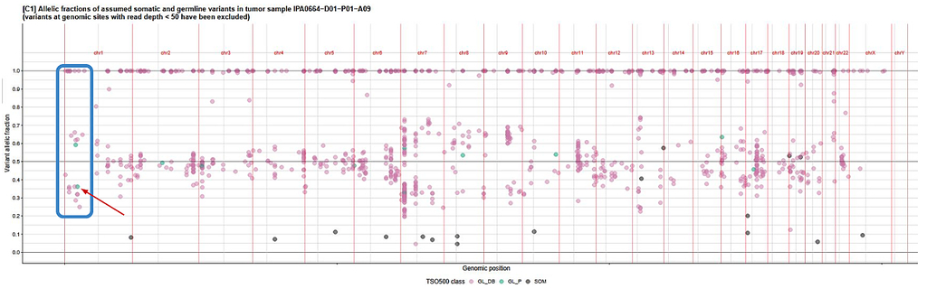

**Figure 9.** VAF plot for case IE1. The RAD54L variant tagged as GL_P is pointed with a red arrow (VAF = 0.36). Note the different VAF value in the nearby area in the chromosome 1 (blue box).

### 4.2 IE2: Two varians next to each other included

In this case we have two variants in the same exon and very close to each other. Both variants are included in the variant list (Figure 10), however most of the times when two variants are very close to each other, this is likely an artifact from the the variant caller or during the alignment and only one variant should be kept. The recommendation is to keep the variant that makes the most sense.

Here we have one variant that is a large deletion of 18 base pair while the other is a mutation right after the deletion (Figure 11). This is probably one variant detected as two different variants. We kept here the large deletion and excluded the single nucleotide variant. When excluding the second variant we wrote a comment in the *Class judgement* column to explain the reason of this decision.

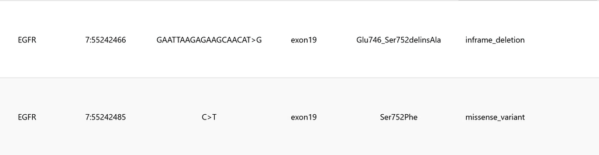

**Figure 10.** In the variant list we can see the two variants on the same exon and coordinate show that they are close to each other.

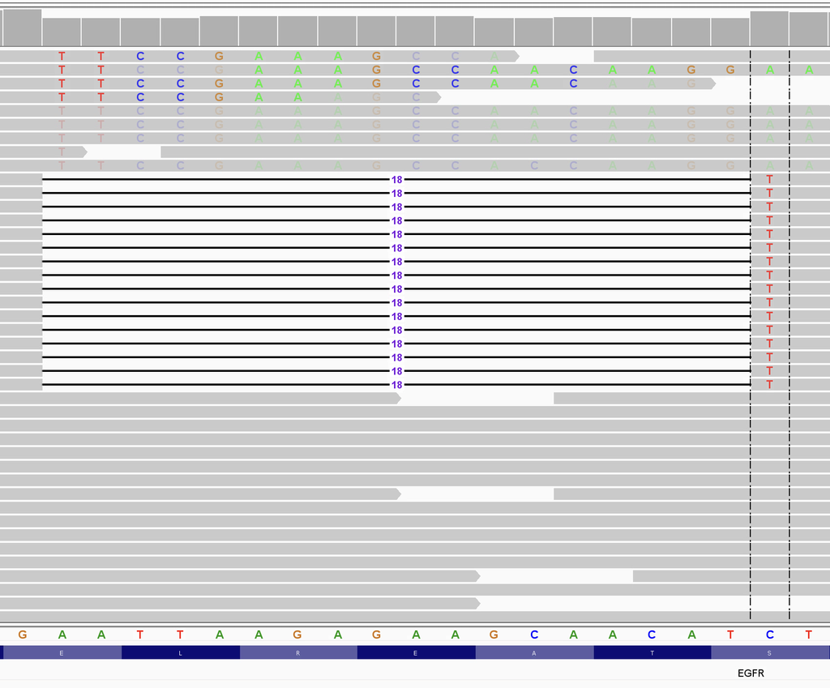

**Figure 11.** On IGV we can actually see that they are the same variant detected as two different variants.

**Explanation**: the 18 nt deletion ends in a *T*, the single nucleotide variant is actually a *C>T* variant, this change actually occurs in the same reads with the deletion.

**Solution**: the single nucleotide variant must be *exclude*d. As it is already accounted in the large deletion.

**Sample**: *IPA0671*

### 4.3 IE3: Same mutational event annotated as separated variants

In this case we have again two *SETD2* variants in the same exon and very close to each other. Both variants are included in the variant list (Figure 12). As we discussed in *IE2*, this may be an artifact from the the variant caller or during the alignment and only one variant should be kept. However in this case the biology suggest something different.

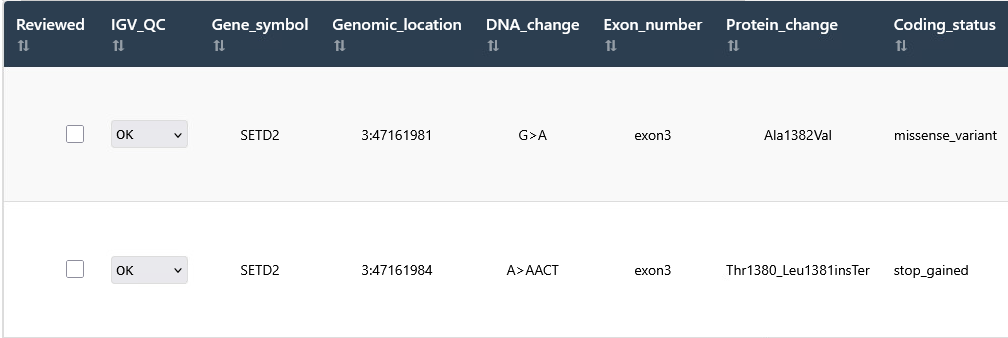

**Figure 12.** Two *SETD2* variants (a SNV and an insertion), non overlapping and separated by a few nucleotides.

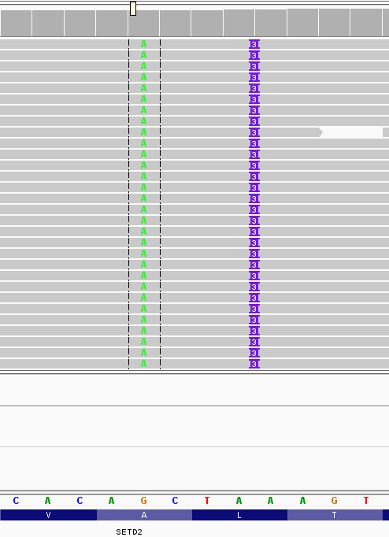

**Figure 13.** We can see that each read has both the SNV and the insertion, we explain this as a same mutational event but annotated separately.

**Explanation**: as the SNV and the insertion are co-occurring in the same reads, it means they are part of the same mutation event. However, the variant annotation software consider them as a separate them events. Conclusion: one mutational event annotated as two (non-overlapping) variants.

**Solution**: as the variants are non overlapping, we consider them as independent entries in the mutation table. Both variants are *include*d but we write a note in both entries.

**Sample**: *IPA0675*

### 4.4 IE4: Variant not detected in RNA reads

In this case, we found a variant in the DNA reads but it is not observed in any of the RNA reads.

This situation may occur frequently and there are many biological and technical explanations.

Biology:

- Not all variants are expressed.
- The variant may be an early *Non-sense* variant that creates an unstable transcript that we never see in the sequencing.

Technical:

- The RNA quality is low: the number of duplicated reads in that locus is high.
- It may be a combination of low tumor content and low VAF.

In this particular example, the variant has a low VAF (0.094) and the tumor content is 40% (Figure 14). We observed that the variant *A>T* is observed in DNA reads, but in none of the RNA reads (Figure 15).

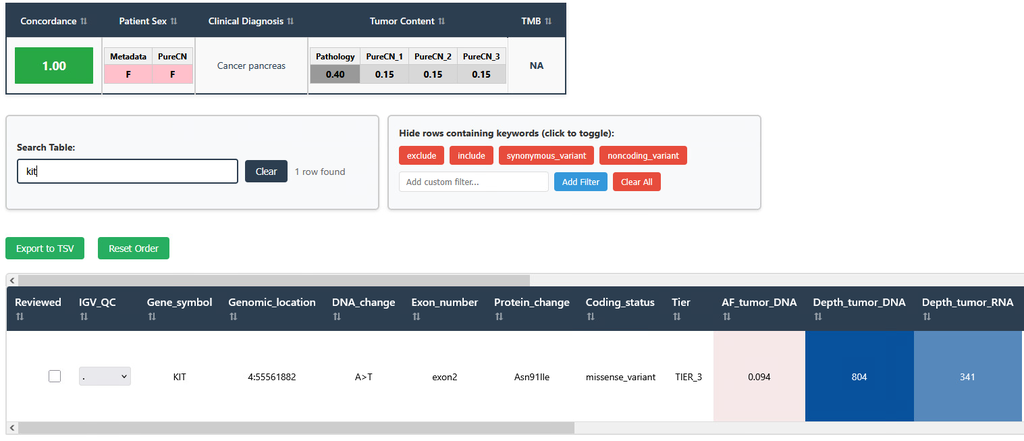

**Figure 14.** VAF and tumor content for a variant observed in DNA reads but not in RNA reads.

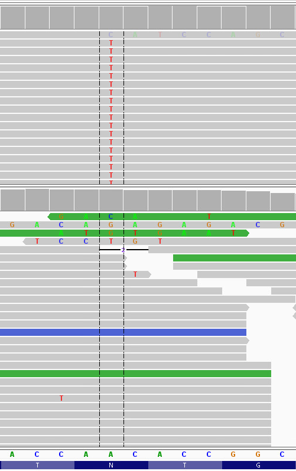

**Figure 15.** The DNA reads (upper panel) contain the *A>T* variant, however we do not observe any read with this variant in the RNA reads (lowe panel).

**Explanation**: it may be a biology or technical issue (see explanation above), this is a common situation, no need to worry about it.

**Solution**: the variant in *include*d.

**Sample**: *IPA0683*

## 5 RV: Recurrent variants

For some reason there are many variants that are recurrently observed in the samples we curate and although frequent, they need to be excluded from the reports. In this section we list those common variants and the explanation of its exclusion.

### 5.1 RV1: BARD1 (2:215632255; CA>TG)

This variant appears frequently in the samples, independently of the cancer type. It is likely an alignment artifact although it is also tagged as a *recurrent germline* (Figure 16).

**Explanation**: the *recurrent germline* tag in this variant is a criterion to *exclude* this variant. In addition, this is a common variant observed in many samples.

**Solution**: verify that this variant is *exclude*d.

**Sample**: *IPA0657*

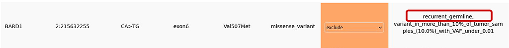

**Figure 16.** BARD1 variant recurrently found in InPreD samples, it is tagged as a recurrent germline variant which is a criterion to exclude it.

## 6 DC: Discordant Cases

This section shows how to proceed when the results of annotated and predicted fields are discordant in a samples (e.g., lower DNA/RNA concordance, predicted and inferred sex is different, etc).

### 6.1 DC1: predicted sex differs in VCF and coverage

In this case we have data from a **male** patient, however the predicted sex in PureCN has two outcomes: **coverage predicts a male** and **VCF is annotated as a female sample** (Figure 17).

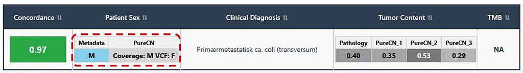

**Figure 17.** In this sample the sex predicted by PureCN differs from the metadata. According to the coverage is a male, and in the VCF is annotated as a female.

We checked the VCF plot and verify that is indeed a male patient (Figure 18), we see that all the germline variants have a *VAF = 1*, which is expected for males, since they have only 1 X chromosome (therefore no heterocigocity).

Note that only *1-22* and *X* chromosomes are displayed in the plots. However chromosome *Y* sequencing reads are available in the *BAM* files.

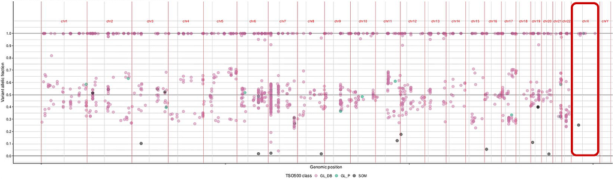

**Figure 18.** The VAF of germline variants in chromosme X is close to 1. Reflecting the homocigocity in this region because males only have one copy of X chromosome.

We must also check the *VCF* result. PureCN calculates a *sex score* (0 for females and 0.5 for males). This score can differ (as in this case; Figure 19) when there is a chromosome Y loss, commonly observed in many tumors.

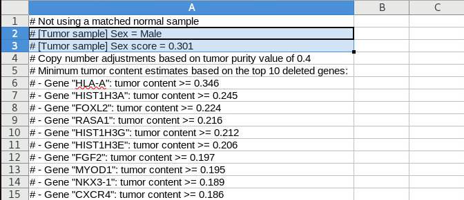

**Figure 19.** Example of *sex score* calculated by PureCN. File: ${sample_id}_merged_CNV_data.tsv within a TSOPPI RUN_ID folder.

**Explanation**: we can verify from the coverage that this is indeed a male sample: VAF in chromosome X is almost 1, reflecting the expected homocigocity for a male individual in this genomic region. The *sex score* (0.3) is closer to the male score (0.5).

**Solution**: we report this warning to the interpreters, as it may be a source of confusion when doing the analysis, it is likely that there is a chromosome Y-loss in this sample, lowering the *sex score* and creating this warning message.

**Sample**: *IPA0666*

### 6.2 DC2: DNA/RNA concordance below the 0.8 threshold

In this case the DNA/RNA conconcordance = 0.77, quite close to the suggested threshold (>= 0.8), Figure 20.

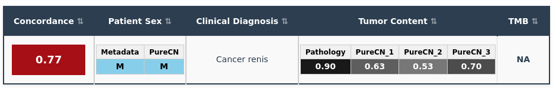

**Figure 20.** Here the *DNA/RNA concordance* was found to be below the threshold.

This could be due to multiple reasons such as chromosome aberration or low quality of RNA sample.

When this happens we have to verify different results:

- **MAD coverage value** (TSO500_run_metrics.pdf): The *MAD CNV coverage* is above the threshold (0.21) in this sample. This suggests that many regions in the genome are amplified or deleted, more than what it is usually expected, suggesting a high degree of genomic aberration (Figure 21).

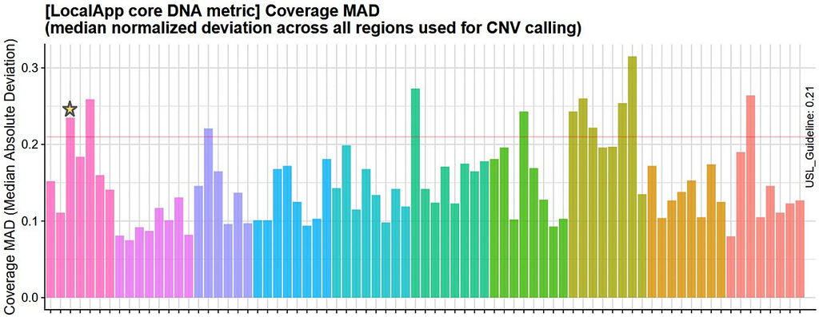

**Figure 21.** Here the *MAD CNV coverage* was found to be above threshold which show that some regions have lower or higher CNV than expected. This could be explained by chromosome aberrations.

- **VAF plot** (CNV_overview_plot.pdf): The VAF plot show a lost of heterozygosity in many chromosomes (1, 2, 3, 6, 9, 10, 13, 17 and 18). If one copy of the chromosome is lost, the VAF of variants in this region will be close to 1 or 0 (instead of 0.5). However because the sample is a mix of normal and tumor sample then the VAF will never be 0 or 1 but a slightly lower than 1 or higher than 0. This is why we observe in the chromosome with loss of heterozygosity a VAF close to 0.8 or 0.2 instead of 0.5 (Figure 22).

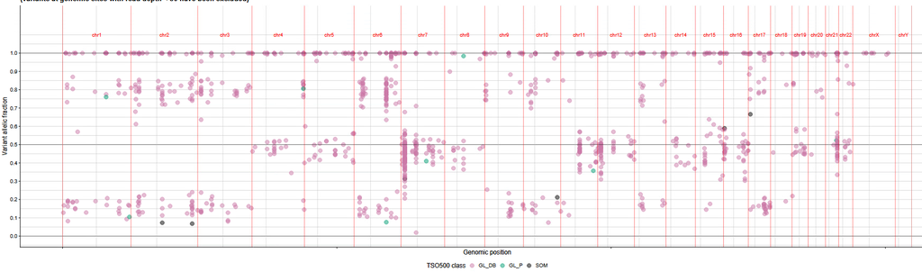

**Figure 22.** The VAF plots shows a mild loss of heterozygosity in some chromosomes (e.g.: 1, 2, 3, 6, 9, 10, 13, 17, 18).

- **CNV plot** (CNV_overview_plot.pdf): The CNV plot shows the loss of copies in some chromosomes and gain of copies in other chromosomes (Figure 23).

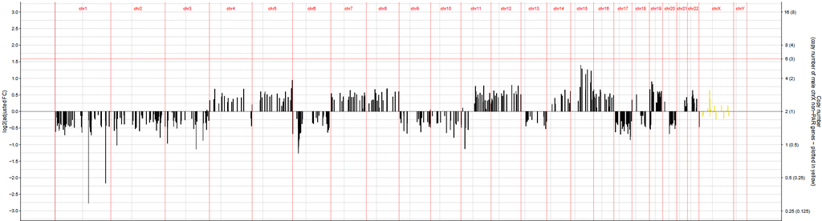

**Figure 23.** The CNV plot shows the copy number variations across different chromosomes.

To verify the quality of the RNA sample we need to compare the coverage range of the RNA alignments and RNA mark duplicates BAM files in IGV.

To do so start IGV without initializing a session and in IGV, go to **File → Load from file**, then navigate to: `TSO500_analyses/${RUN_ID}/Logs_intermediates/RnaAlignment/${sample_id}/${sample_id}.bam`

Also load: `TSO500_analyses/${RUN_ID}/Logs_intermediates/RnaMarkDuplicates/${sample_id}/${sample_id}.bam`

In Figure 24 we can see a large difference in coverage range between these two tracks *RnaAlignment* and *RnAMarkDuplicates*. This large difference indicate a large amount of duplicates which may indicate a low quality of the RNA sample. This could explain the low DNA/RNA concordance in this sample.

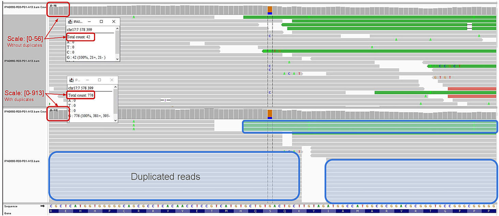

**Figure 24.** The IGV tracks show the coverage range of the RNA alignments and RNA mark duplicates BAM files.

**Explanation**: Here the low DNA/RNA concordance is likely explained by a mix of both low quality and chromosome aberrations in this sample.

**Solution**: we report this warning to the interpreters, as it may be a source of confusion when doing the analysis. The concordance is close to the threshold so the data is still usable.

**Sample**: *IPA0660*

## 7 CV: Change Variant Cases

This section shows how to proceed when a predicted variants is incorrect, probably due to an alignment issue, but another proximal variant, originally included in the predicted variant, makes more sense to be reported.

In this case we have a reported 3 nucleotide insertion, however we see in the alignment that the 3rd position is a SNV *T>C*, and it is not reported by the predictor (Figure 25).

Looking at the insertion sequence, we noticed that it is flanked by two *AGC* sequences, if we consider the SNV in the third position, we observe 3 *ACG* repeats. The *VAF* of the *T>C* is 1, that means, all reads contain this SNV, therefore it seems that the aligner is confused and assign that as a deletion.

However, the *T>C* is not in the list of reported variants.

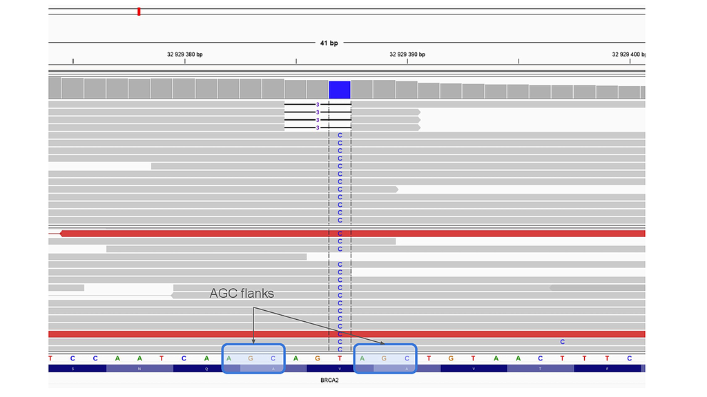

**Sample**: *IPA0728*